# Practical Machine Learning-Predicting Exercise Activities

May 21, 2016

## Overview

The Weight Lifting Exercise data set is modeled to predict how a person performs the exercises. After some exploring of the data, the features used for identification or derived from the measured data are excluded. The remaining features related to measurements of movements of exercise participants are selected as predictors in a random forest model to predict performance. This model’s predictions for a validation data set have an accuracy similar to the one calculated from the out-of-bag error estimate of the model.

## Exploratory Data Analysis and Predictor Selection

The Weight Lifting Exercise data has a training set and a testing set as follows:

```
##           Rows Columns
## Training 19622     160
## Testing     20     160
```

The training set is for model generation, and the testing set is for the quiz. The training set has 19622 observations and 160 variables of dumbbell exercises performed by six participants. The last variable $classe$ is the performance classifier to be predicted.

| Class | Description |
| --- | --- |
| A | Exactly according to specification |
| B | Throwing elbows to the front |
| C | Lifting the dumbbell halfway |
| D | Lowering the dumbbell halfway |
| E | Throwing hips to the front |

The other variables are related to identifications, measurements and their statistics. For more details on this data set see [Velloso et al.](http://groupware.les.inf.puc-rio.br/har)

The first 7 features identifying the participants and times are excluded. There are 100 features referring to statistics of measurements with kurtosis, skewness, max, min, amplitude, stddev, avg, and var in variable names. These features are also excluded because they are incomplete and derived from measurements. The remaining features are screened for correlations with a 75% cutoff. There are 21 features excluded because of high correlation. The remaining 31 are predictors selected for modeling. A summary of features and an example summary of an identifier, a statistic and a predictor are below:

```
##                  Features
## Total                 159
## Id                      7
## Derived               100
## High Correlation       21
## Predictor              31
```

```
##     user_name    stddev_yaw_belt      yaw_belt
##  adelmo  :3892   Min.   :  0.000   Min.   :-180.00
##  carlitos:3112   1st Qu.:  0.100   1st Qu.: -88.30
##  charles :3536   Median :  0.300   Median : -13.00
##  eurico  :3070   Mean   :  1.341   Mean   : -11.21
##  jeremy  :3402   3rd Qu.:  0.700   3rd Qu.:  12.90
##  pedro   :2610   Max.   :176.600   Max.   : 179.00
##                  NA's   :19216
```

The following plot is the plot of the classifiers against two of the predictors.

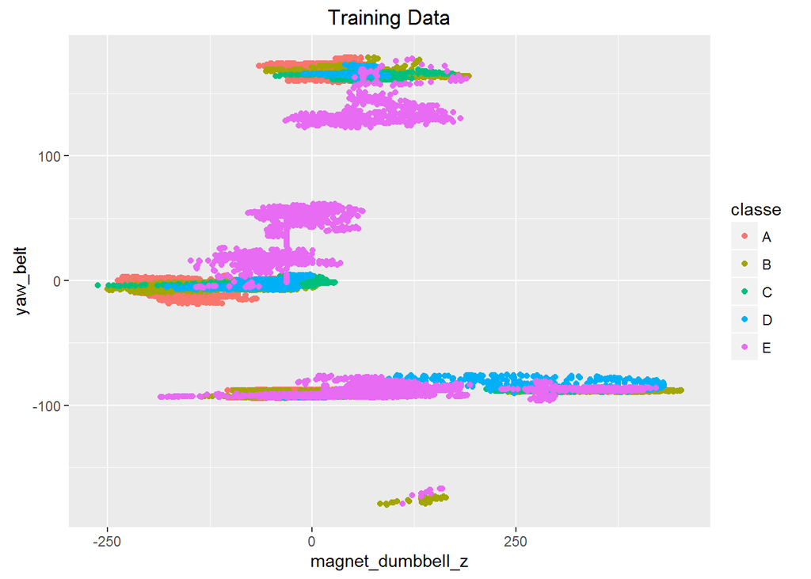

## Fitting Random Forest Model

The original training data set is split 70:30 into two sets for training and validation, respectively.

The predictors in the split training data set are fitted to a random forest model to predict the $classe$ performance classifier. The random forest (rf) method in the caret package is used with default options.

#### Out-of-Bag Error Estimates

The plot of out-of-bag error estimates is below.

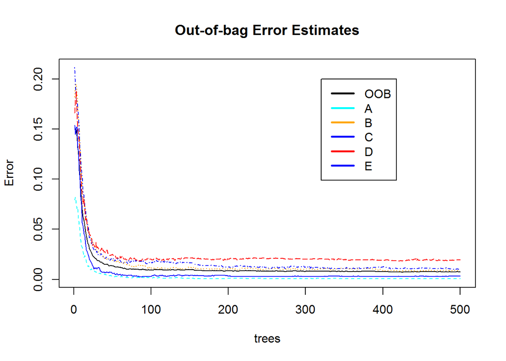

The out-of-bag error decreases with the number of trees and flatens out at about 0.7%.

#### Gini Importance

The plot of Gini importance is below.

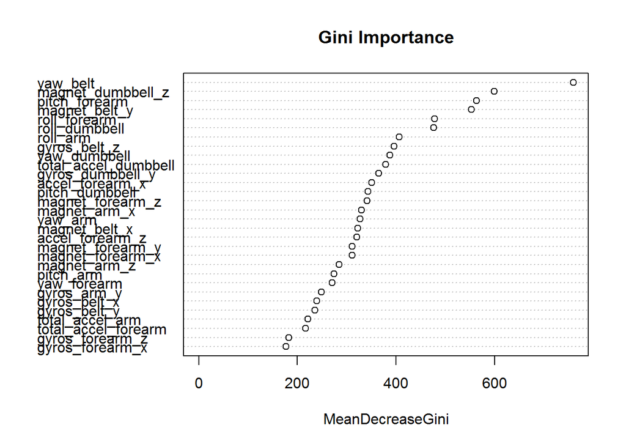

The top 7 important predictors are yaw_belt, magnet_dumbbell_z, pitch_forearm, magnet_belt_y, roll_forearm, roll_dumbbell and roll_arm.

#### Validation and Accuracy

Following are the confusion matrices of the training and validation data sets:

```
##           Training Classe
## Prediction    A    B    C    D    E
##          A 3906    0    0    0    0
##          B    0 2658    0    0    0
##          C    0    0 2396    0    0
##          D    0    0    0 2252    0
##          E    0    0    0    0 2525
```

```
##           Validation Classe
## Prediction    A    B    C    D    E
##          A 1674    8    0    0    0
##          B    0 1129    7    0    0
##          C    0    2 1012   16    0
##          D    0    0    7  946    2
##          E    0    0    0    2 1080
```

```
##             Accuracy
## Training   1.0000000
## Validation 0.9925234
```

The random forest model predicts correctly all performance classifiers in the split training data set. For the validation data set, the prediction accuracy is 99.3%. This validation accuracy is in line with the out-of-bag error estimate of 0.7% or 99.3% accuracy.

The plot below shows the correct and incorrect predictions for the validation data set.

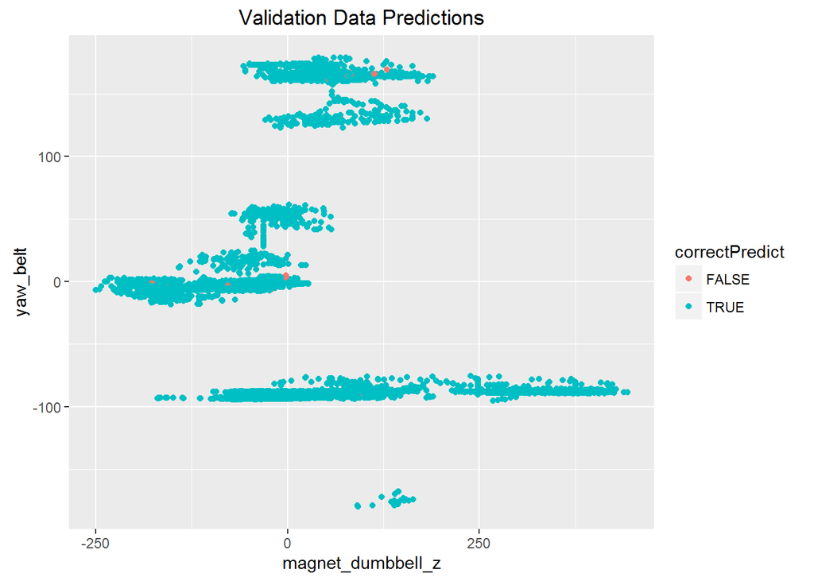

## Conlusions

The random forest model fits the selected predictors to predict the excercise performance classifiers of the split training and validation data sets with 100.0% and 99.3% accuracy, respectively.

Although cross-validation is unnecessary for random forest models (see [Breiman and Cutler](http://www.stat.berkeley.edu/~breiman/RandomForests/cc_home.htm#ooberr)), the validation step is done to show that the validation accuracy of the model is comparable to the accuracy calculated from the out-of-bag error estimate of the model.